# 18 - Differential Methylation & PAV: Gene Annotation and Phenotype Synthesis

Lean vs Siscowet Lake Trout on GCF_016432855.1 (SaNama_1.0)

project-lake-trout

2026-06-13

# Overview

This report synthesizes the gene-annotation work (Steps 0–4 of `code/18-diff-annotation-phenotype-plan.md`) into a ranked candidate-gene interpretation and a set of **hypothesized phenotypic consequences** for the lean and siscowet ecotypes. It does not generate new variant calls; it asks *where* the existing differential methylation (DMRs/DMCs) and differential PAVs fall, *what* those genes do, and *which ecotype phenotypes* they could plausibly affect.

## Read-this-first caveat: the reference is a *lean* genome

> GCF_016432855.1 was assembled from a female gynogenetic **doubled haploid** of the **Seneca Lake (NY) brood stock** — a documented **lean** morphotype (Smith et al. 2022, *Mol Ecol Resour*). Every ecotype-asymmetric result here is therefore **lean-reference biased**: siscowet diverges more from the reference, inflating apparent siscowet-specific PAVs and reducing siscowet CpG coverage in divergent regions. Interpret all PAV magnitudes comparatively, never as absolute counts, and treat siscowet-specific gene *content* as partially invisible to a reference-only analysis.

| Layer | File | Built by |
| --- | --- | --- |
| Gene function table | `gene_function_table.tsv` | `code/18-build-gene-function-table.py` |
| DMR → gene | `dmr_gene_assignments.tsv` | `code/18.1-assign-features-to-genes.py` |
| DMC → gene | `dmc_gene_assignments.tsv` | `code/18.1-...` |
| Stringent PAV → gene | `pav_gene_assignments.tsv` | `code/18.1-...` |
| Lenient PAV burden | `pav_gene_burden.tsv` | `code/18.1-...` |
| Integrated candidates | `integrated_candidate_genes.tsv` | `code/18.2-integrate-candidates.py` |
| GO enrichment | `go_enrichment_{dmr,pav,union}.tsv` | `code/18.3-go-enrichment.py` |

Positional windows: promoter = TSS ± 2 kb (strand-aware); flanking = gene body ± 5 kb. GO ORA is hypergeometric on local NCBI GO annotations with DAG propagation, BH-FDR within each set.

# Results

```r
cand <- rd("integrated_candidate_genes.tsv")
dmr  <- rd("dmr_gene_assignments.tsv")
pav  <- rd("pav_gene_assignments.tsv")
go_pav <- rd("go_enrichment_pav.tsv")
num <- function(x) suppressWarnings(as.numeric(x))
```

## Summary

```r
summ <- data.frame(
  Metric = c("Candidate genes (DMR/DMC/stringent-PAV within 5 kb)",
             "  with a DMR within 5 kb",
             "  with a stringent siscowet-specific deletion within 5 kb",
             "  CONVERGENT (DMR and stringent PAV)",
             "DMRs landing in a promoter (TSS +/- 2 kb)",
             "Genes with an EXON-overlapping siscowet-specific deletion",
             "GO terms FDR<0.1 (PAV set)"),
  Value = c(nrow(cand),
            sum(num(cand$dmr_n) > 0),
            sum(num(cand$pav_strin_n) > 0),
            sum(cand$convergent == 1),
            sum(dmr$in_promoter == 1),
            length(unique(pav$gene_id[pav$exon_overlap == 1])),
            sum(num(go_pav$fdr) < 0.1)))
kt(summ, "Headline numbers")
```

Headline numbers

| Metric | Value |
| --- | --- |
| Candidate genes (DMR/DMC/stringent-PAV within 5 kb) | 2036 |
| with a DMR within 5 kb | 181 |
| with a stringent siscowet-specific deletion within 5 kb | 1263 |
| CONVERGENT (DMR and stringent PAV) | 4 |
| DMRs landing in a promoter (TSS +/- 2 kb) | 88 |
| Genes with an EXON-overlapping siscowet-specific deletion | 54 |
| GO terms FDR<0.1 (PAV set) | 78 |

## Convergent genes (methylation *and* structural variation)

The strongest candidates carry both a DMR and a stringent siscowet-specific deletion.

```r
cv <- cand[cand$convergent == 1,
           c("symbol","product","dmr_directions","dmr_best_class","dmr_max_absdiff",
             "pav_strin_best_class","pav_strin_exonic","pav_strin_maxsize","rank_score")]
kt(cv, "Convergent candidate genes")
```

Convergent candidate genes

| symbol | product | dmr_directions | dmr_best_class | dmr_max_absdiff | pav_strin_best_class | pav_strin_exonic | pav_strin_maxsize | rank_score |
| --- | --- | --- | --- | --- | --- | --- | --- | --- |
| LOC120032414 | zinc finger protein 883-like | hyper_siscowet | exon | 28.77 | exon | 1 | 270 | 6 |
| LOC120040411 | gastrula zinc finger protein XlCGF57.1-like | hypo_siscowet | intron | 56.06 | intron | 0 | 208 | 4 |
| LOC120039781 |  | hypo_siscowet | intron | 20.40 | intron | 0 | 729 | 4 |
| LOC120043843 | septin-9-like | hyper_siscowet | intron | 16.51 | intron | 0 | 422 | 3 |

Two of the four (`znf883`-like paralogs, `XlCGF57.1`-like) are rapidly-evolving, tandemly-arrayed zinc-finger genes — convergence there partly reflects **repetitive-region mapping**, so they are flagged rather than asserted.

## Protein-coding genes with promoter methylation

Promoter DMRs are the most interpretable methylation signal (regulatory potential). Repetitive ncRNA (rDNA/snRNA) loci are excluded.

```r
pc <- cand[cand$dmr_promoter == 1 & cand$biotype == "protein_coding" & cand$caution == "",
           c("symbol","product","dmr_directions","dmr_max_absdiff",
             "log2fc_sisco_lean","meth_expr_concordant")]
pc <- pc[order(-num(pc$dmr_max_absdiff)), ]
kt(head(pc, 15), "Protein-coding promoter-DMR genes (top 15 by methylation difference)")
```

Protein-coding promoter-DMR genes (top 15 by methylation difference)

| symbol | product | dmr_directions | dmr_max_absdiff | log2fc_sisco_lean | meth_expr_concordant |
| --- | --- | --- | --- | --- | --- |
| LOC120029926 | epoxide hydrolase 1-like | hypo_siscowet | 44.54 | 0.04 | flat |
| LOC120051555 | zinc finger protein 665-like | hypo_siscowet | 34.52 | NA | NA |
| rbm24b | RNA binding motif protein 24b | hyper_siscowet | 32.77 | NA | NA |
| LOC120036681 | OCIA domain-containing protein 1-like | hypo_siscowet | 30.73 | 0.10 | flat |
| LOC120041959 | uncharacterized LOC120041959 | hypo_siscowet | 24.72 | NA | NA |
| LOC120033896 | small G protein signaling modulator 3-like | hypo_siscowet | 17.21 | NA | NA |

## Exonic siscowet-specific deletions (candidate copy-number / loss-of-function)

```r
ex <- pav[pav$exon_overlap == 1, c("symbol","product","size_bp","chrom","start","end")]
ex <- ex[order(-num(ex$size_bp)), ]
ex <- ex[!duplicated(ex$symbol), ]
kt(head(ex, 15), "Largest exon-overlapping siscowet-specific deletions (one row per gene)")
```

Largest exon-overlapping siscowet-specific deletions (one row per gene)

| symbol | product | size_bp | chrom | start | end |
| --- | --- | --- | --- | --- | --- |
| LOC120023451 |  | 7696 | NC_052308.1 | 73682627 | 73690323 |
| LOC120043798 | deleted in malignant brain tumors 1 protein-like | 5648 | NC_052309.1 | 96977772 | 96983420 |
| LOC120058315 | carcinoembryonic antigen-related cell adhesion molecule 1-like | 5638 | NC_052319.1 | 18640816 | 18646454 |
| LOC120035267 | uncharacterized LOC120035267 | 4413 | NW_024057675.1 | 687095 | 691508 |
| LOC120050008 | angiopoietin-related protein 5-like | 3144 | NC_052312.1 | 40398448 | 40401592 |
| LOC120050007 |  | 3144 | NC_052312.1 | 40398448 | 40401592 |
| LOC120036302 | mucin-2-like | 2565 | NW_024058002.1 | 34668 | 37233 |
| LOC120051533 | OX-2 membrane glycoprotein-like | 1672 | NC_052313.1 | 59088687 | 59090359 |
| LOC120043299 | NLR family CARD domain-containing protein 3-like | 1283 | NW_024061633.1 | 41624 | 42907 |
| LOC120023687 | junctional adhesion molecule A-like | 1261 | NC_052308.1 | 78179875 | 78181136 |
| LOC120040975 | E3 ubiquitin/ISG15 ligase TRIM25-like | 1258 | NW_024060988.1 | 11154 | 12412 |
| LOC120040528 | uncharacterized LOC120040528 | 1240 | NW_024060564.1 | 209111 | 210351 |
| LOC120042792 | uncharacterized LOC120042792 | 1167 | NW_024061508.1 | 45203 | 46370 |
| LOC120041182 | rab effector MyRIP-like | 1130 | NW_024061099.1 | 87943 | 89073 |
| LOC120044082 | voltage-dependent T-type calcium channel subunit alpha-1I-like | 715 | NC_052309.1 | 83776879 | 83777594 |

## GO enrichment — the defensible signal

```r
g <- go_pav[num(go_pav$fdr) < 0.25,
            c("name","namespace","study_k","fold_enrichment","fdr","phenotype")]
g <- g[order(num(g$fdr)), ]
kt(head(g, 20), "PAV-set GO terms at FDR<0.25 (phenotype-relevant flagged in 'phenotype')")
```

PAV-set GO terms at FDR<0.25 (phenotype-relevant flagged in ‘phenotype’)

| name | namespace | study_k | fold_enrichment | fdr | phenotype |
| --- | --- | --- | --- | --- | --- |
| calcium ion transmembrane transporter activity | molecular_function | 23 | 3.52 | 0.0002561 |  |
| calcium ion transmembrane transport | biological_process | 19 | 3.74 | 0.0005607 |  |
| neuron projection development | biological_process | 33 | 2.35 | 0.0026120 |  |
| calcium channel complex | cellular_component | 12 | 4.58 | 0.0029770 |  |
| neuron development | biological_process | 34 | 2.22 | 0.0029770 |  |
| cell projection morphogenesis | biological_process | 27 | 2.45 | 0.0029770 |  |
| plasma membrane bounded cell projection morphogenesis | biological_process | 27 | 2.45 | 0.0029770 |  |
| neuron projection morphogenesis | biological_process | 27 | 2.45 | 0.0029770 |  |
| calcium ion transport | biological_process | 19 | 3.00 | 0.0029770 | Y |
| calcium channel activity | molecular_function | 17 | 3.23 | 0.0029770 |  |
| mechanosensitive monoatomic ion channel activity | molecular_function | 6 | 9.07 | 0.0042080 |  |
| cell morphogenesis involved in neuron differentiation | biological_process | 24 | 2.45 | 0.0059990 |  |
| neuron projection guidance | biological_process | 20 | 2.66 | 0.0067010 |  |
| axon guidance | biological_process | 20 | 2.66 | 0.0067010 |  |
| generation of neurons | biological_process | 40 | 1.91 | 0.0067010 |  |
| cell development | biological_process | 45 | 1.83 | 0.0067010 |  |
| semaphorin receptor activity | molecular_function | 7 | 6.19 | 0.0084130 |  |
| voltage-gated calcium channel complex | cellular_component | 9 | 4.60 | 0.0089410 |  |
| axonogenesis | biological_process | 22 | 2.42 | 0.0089410 |  |
| neuron differentiation | biological_process | 38 | 1.90 | 0.0089410 |  |

## Top candidates figure

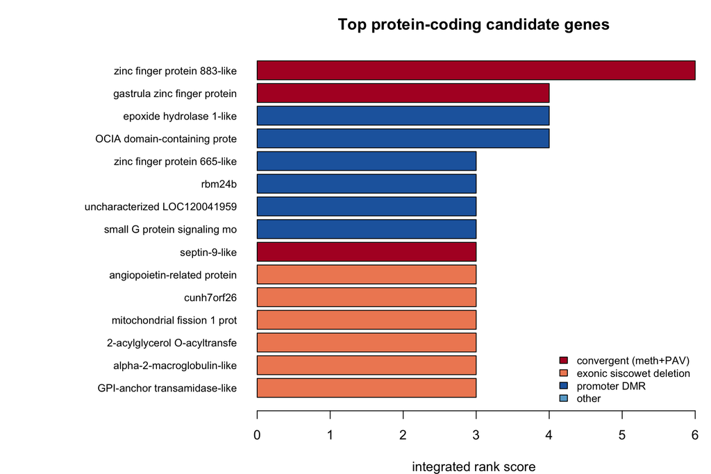

```r
top <- cand[cand$caution == "" & cand$biotype == "protein_coding", ]
top <- top[order(-num(top$rank_score), -num(top$dmr_max_absdiff)), ]
top <- head(top, 15)
lab <- ifelse(top$symbol == "" | grepl("^LOC", top$symbol),
              substr(top$product, 1, 28), top$symbol)
lab[lab == ""] <- top$gene_id[lab == ""]
col <- ifelse(top$convergent == 1, "#b2182b",
       ifelse(top$pav_strin_exonic == 1, "#ef8a62",
       ifelse(top$dmr_promoter == 1, "#2166ac", "#67a9cf")))
op <- par(mar = c(4, 16, 3, 1))
bp <- barplot(rev(num(top$rank_score)), horiz = TRUE, names.arg = rev(lab),
              las = 1, col = rev(col), xlab = "integrated rank score",
              main = "Top protein-coding candidate genes", cex.names = 0.8)
legend("bottomright", bty = "n", cex = 0.8,
       fill = c("#b2182b","#ef8a62","#2166ac","#67a9cf"),
       legend = c("convergent (meth+PAV)","exonic siscowet deletion",
                  "promoter DMR","other"))
```

```r
par(op)
dir.create("figures", showWarnings = FALSE)
png("figures/18-top-candidates.png", width = 900, height = 600)
par(mar = c(4, 16, 3, 1))
barplot(rev(num(top$rank_score)), horiz = TRUE, names.arg = rev(lab), las = 1,
        col = rev(col), xlab = "integrated rank score",
        main = "Top protein-coding candidate genes", cex.names = 0.8)
invisible(dev.off())
```

# Phenotype interpretation

Lean and siscowet differ along well-characterized axes: **lipid content / energy storage** (siscowet are fatty, deep-water; lean are lean-bodied, shallow), **body shape and size**, **depth / pressure / buoyancy**, and **sensory–neuromuscular** performance. The repository’s own `data/measurements.xlsx` is a 17-landmark **geometric-morphometric** data set (body shape + centroid size) for ~100 fish per group — direct evidence that the ecotypes differ in *body form and size*, which is the phenotype the growth/muscle candidates below would feed into. Each block states the evidence and an explicitly **hypothesized** link.

### Lipid metabolism / energy storage *(gene-level, not genome-wide)*

- **`angptl5`** (angiopoietin-related protein 5-like) — exonic siscowet-specific deletion. ANGPTL family members regulate **triglyceride / lipoprotein-lipase activity**. Hypothesis: altered lipid-handling capacity, consistent with the defining lean/siscowet fat-content difference. *Caveat: lean-reference bias means this is a candidate, not a confirmed siscowet loss.*
- **`mogat2`** (2-acylglycerol O-acyltransferase 2-A-like) — exonic deletion. Catalyses **triacylglycerol synthesis** (monoacylglycerol pathway). Hypothesis: differential dietary lipid re-esterification / fat deposition.
- **Epoxide hydrolase 1-like** (LOC120029926) — promoter DMR (hypo in siscowet). Roles in lipid-epoxide and xenobiotic metabolism.
- **Genome-wide caveat:** GO enrichment does **not** support a broad lipid-metabolism program (broad lipid terms are depleted; only narrow lipid-binding sub-terms are weakly enriched, FDR>0.1). The lipid signal here is **individual-gene**, not pathway-level.

### Calcium signalling, excitability, and sensory–neural

- **Calcium ion transport** is the one phenotype-relevant GO block passing FDR<0.1 in the PAV set; **calcium-channel** and **axon-guidance / neuron-projection** terms top the list. Specific genes include a **T-type calcium channel α-1I-like** subunit (exonic deletion), **CaMKII β-like** (near a DMR), and **anoctamin-10a** (Ca-gated channel, near a DMR). Hypothesis: differences in neuromuscular excitability / sensory tuning relevant to deep-water (siscowet) vs shallow (lean) life history. *Strong gene-length caveat applies.*

### Immune / cell-surface recognition

- Exonic siscowet-specific deletions cluster in **immune & adhesion** genes: CEACAM1-like, CD200/OX-2-like, DMBT1-like, NLRP3-like, α-2-macroglobulin-like, TRIM25-like, CD22-like. These gene families are **rapidly evolving and copy-number-variable** across vertebrates, so some of this is expected background rather than ecotype-specific selection. Hypothesis: ecotype differences in pathogen/parasite exposure (note the companion liver RNAseq is a parasitized/non-parasitized study) — but this is the class **most** confounded by reference bias and gene-family CNV.

### Chromatin / transcriptional regulation *(flagged as artifact)*

- The DMR GO enrichment (chromatin/nucleosome, transcription-repressor) is driven by **one histone gene cluster** (6 co-located histones) and **three adjacent `znf883` paralogs** — a tandem-cluster artifact, not broad regulatory convergence. Reported for completeness only.

# Limitations

1. **Reference is lean** — all ecotype-asymmetric signals are divergence-biased; siscowet gene content absent from the reference is invisible. The per-ecotype hifiasm track (`code/13.3-...plan.md`) is the needed complement.
2. **No DMC survives FDR** (q<0.1 = 0 in the diff-meth report); interpretation leans on DMR-level and stringent-PAV sets. Single-CpG and lenient-PAV signals are hypothesis-generating only.
3. **Expression is orthogonal, not confirmatory** — the liver RNAseq is a *different study / different individuals*; most candidates are not liver-expressed (`log2fc=NA`).
4. **Gene-length bias** inflates PAV-based GO enrichment toward long genes (calcium channels); a length-matched permutation null is the proper test (not yet run).
5. **Tandem-cluster / paralog inflation** and **IEA-only GO annotations** affect enrichment.
6. **Associative, not causal** — promoter-hypermethylation → silencing is a hypothesis; no functional validation, single reference, no replication across additional assemblies.

# Conclusions

The cleanest, most defensible findings are: (i) a small set of **convergent** genes (led by a `znf883` paralog), (ii) a **calcium-transport / channel** GO signal in the structural-variant set (with a gene-length caveat), and (iii) **individual** lipid-metabolism genes (`angptl5`, `mogat2`) and a high-effect **muscle-development** promoter DMR (`rbm24b`) that align with the known lipid- and body-shape differences between the ecotypes — the latter directly relevant to the morphometric phenotypes recorded in `data/measurements.xlsx`. None of these are confirmed; they are prioritized hypotheses for targeted follow-up on ecotype-specific (hifiasm) assemblies and in matched tissue.